# Lecture 24 Markdown

Prof. Sheng-Luen Chung

## 作業4：Data Mining, due 6/7 (五) 早上 9:00

將 R Markdown 檔以：姓名_學號為主檔名命名， 寄給助教：willy655042@gmail.com 並 cc 給我：slchung@mail.ntust.edu.tw

*What a Multivariate Logistic Regression Data Set Looks Like: An Example*

http://logisticregressionanalysis.com/303-what-a-logistic-regression-data-set-looks-like-an-example/

### The Context – A Data Mining Example

In this example, a magazine reseller is trying to decide what magazines to market to customers. In the “old days,” this might have involved trying to decide which customers to send advertisements to via regular mail. In the context of today and the “web,” this might involved deciding what recommendations to make to a customer viewing a web page about other items that the customer might be interested in and therefore want to buy. The two problem are essentially the same.

# Factors in Regression (Chapter 13, “Linear Models with R” by Julian Faraway)

$$http://www.utstat.toronto.edu/~brunner/books/LinearModelsWithR.pdf$$

# 如何解釋分類 (Categorical’ Factor) 性質的解釋變數呢？

## Predictors that are qualitative in nature are described as categorical variables or factors.

用來當作解釋變數本身即為定性的 (vs 定量)，本質上比較像是「分類性 (categorial) 變數」或者就稱之為因子 (factor)

## A Two-level Factor Example

$$https://www.rdocumentation.org/packages/faraway/versions/1.0.7$$

創傷後壓力症（Post-traumatic stress disorder，簡稱PTSD，又稱創傷後遺症）

```r
library(faraway)
data(sexab)
```

1. The response variable is ptsd (Post-traumatic stress disorder on standard scale).
2. Explanatory variables are csa (childhood sexual abuse) which is a *binary* variable and cpa (childhood physical abuse) which is a *quantitative* variable.

```r
str(sexab)
```

```
## 'data.frame':    76 obs. of  3 variables:
##  $ cpa : num  2.048 0.839 -0.241 -1.115 2.015 ...
##  $ ptsd: num  9.71 6.17 15.16 11.31 9.95 ...
##  $ csa : Factor w/ 2 levels "Abused","NotAbused": 1 1 1 1 1 1 1 1 1 1 ...
```

```r
head(sexab)
```

```
##        cpa     ptsd    csa
## 1  2.04786  9.71365 Abused
## 2  0.83895  6.16933 Abused
## 3 -0.24139 15.15926 Abused
## 4 -1.11461 11.31277 Abused
## 5  2.01468  9.95384 Abused
## 6  6.71131  9.83884 Abused
```

```r
tail(sexab)
```

```
##         cpa     ptsd       csa
## 71 -0.31402 -0.14339 NotAbused
## 72  2.17626  6.57281 NotAbused
## 73 -0.23208 -3.11622 NotAbused
## 74 -1.85753 -0.46996 NotAbused
## 75  2.85253  6.84304 NotAbused
## 76  0.81138  7.12918 NotAbused
```

```r
summary(sexab)
```

```
##       cpa               ptsd               csa
##  Min.   :-3.1204   Min.   :-3.349   Abused   :45
##  1st Qu.: 0.8321   1st Qu.: 6.173   NotAbused:31
##  Median : 2.0707   Median : 8.909
##  Mean   : 2.3547   Mean   : 8.986
##  3rd Qu.: 3.7387   3rd Qu.:12.240
##  Max.   : 8.6469   Max.   :18.993
```

這兩類是不同屬性的解釋變數

```r
class(sexab[,1])
```

```
## [1] "numeric"
```

```r
class(sexab[,3])
```

```
## [1] "factor"
```

## A factor specifies a discrete classification(grouping)

# by() is used to apply a function to a data frame split by a factor.

將整個 sexab 的表，按 sexab$csa 來作 summary

```r
by(sexab, sexab$csa, summary)
```

```
## sexab$csa: Abused
##       cpa              ptsd               csa
##  Min.   :-1.115   Min.   : 5.985   Abused   :45
##  1st Qu.: 1.415   1st Qu.: 9.374   NotAbused: 0
##  Median : 2.627   Median :11.313
##  Mean   : 3.075   Mean   :11.941
##  3rd Qu.: 4.317   3rd Qu.:14.901
##  Max.   : 8.647   Max.   :18.993
## --------------------------------------------------------
## sexab$csa: NotAbused
##       cpa               ptsd               csa
##  Min.   :-3.1204   Min.   :-3.349   Abused   : 0
##  1st Qu.:-0.2299   1st Qu.: 3.544   NotAbused:31
##  Median : 1.3216   Median : 5.794
##  Mean   : 1.3088   Mean   : 4.696
##  3rd Qu.: 2.8309   3rd Qu.: 6.838
##  Max.   : 5.0497   Max.   :10.914
```

## 不只如此，也可以分類畫圖

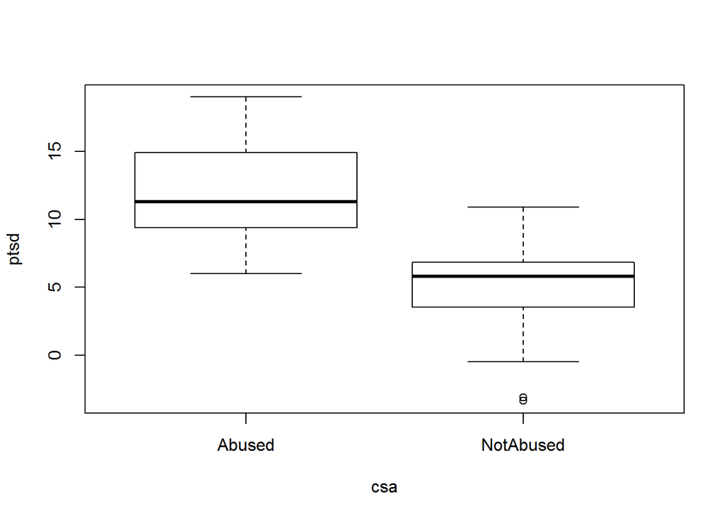

```r
plot(ptsd ~ csa, sexab)
```

We see that those in abused group have higher levels of PTSD than those in the nonabused group. We can test this difference by using linear regression.

```r
 g1 <- lm(ptsd ~ csa, sexab)
 summary(g1)
```

```
##
## Call:
## lm(formula = ptsd ~ csa, data = sexab)
##
## Residuals:
##     Min      1Q  Median      3Q     Max
## -8.0451 -2.3123  0.0951  2.1645  7.0514
##
## Coefficients:
##              Estimate Std. Error t value Pr(>|t|)
## (Intercept)   11.9411     0.5177  23.067  < 2e-16 ***
## csaNotAbused  -7.2452     0.8105  -8.939 2.17e-13 ***
## ---
## Signif. codes:  0 '***' 0.001 '**' 0.01 '*' 0.05 '.' 0.1 ' ' 1
##
## Residual standard error: 3.473 on 74 degrees of freedom
## Multiple R-squared:  0.5192, Adjusted R-squared:  0.5127
## F-statistic:  79.9 on 1 and 74 DF,  p-value: 2.172e-13
```

# 以下解釋 factor variable 是怎麼編碼的？

1. We see that “Abused” is coded as zero and “NotAbused” is coded as one.
2. The default is made alphabetically. This means that “Abused” is the reference level here and that the parameters represent the difference between “NotAbused” and this reference level.

## Can you interpret the coefficients now?

預設是 “Abused” 也就是假設全部都有外 abused，所以當遇到的情況是 “NotAbused” 時，他在回歸分析的公式上，有一個負的係數項。

這感覺怪怪的，應該是要假設 “NotAbused” 的才比較好。但，我們要怎麼反應在公式上呢？

## You can change the reference level to “NotAbused”:

```r
sexab$csa <- relevel(sexab$csa,ref="NotAbused")
```

## How do you expect the coefficients to change?

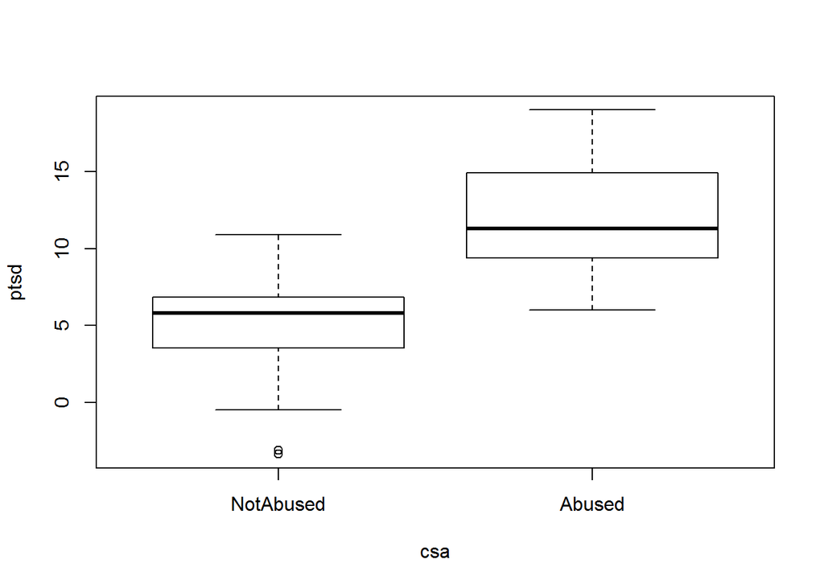

```r
plot(ptsd ~ csa, sexab)
```

```r
g1 <- lm(ptsd ~ csa, data=sexab)
summary(g1)
```

```
##
## Call:
## lm(formula = ptsd ~ csa, data = sexab)
##
## Residuals:
##     Min      1Q  Median      3Q     Max
## -8.0451 -2.3123  0.0951  2.1645  7.0514
##
## Coefficients:
##             Estimate Std. Error t value Pr(>|t|)
## (Intercept)   4.6959     0.6237   7.529 1.00e-10 ***
## csaAbused     7.2452     0.8105   8.939 2.17e-13 ***
## ---
## Signif. codes:  0 '***' 0.001 '**' 0.01 '*' 0.05 '.' 0.1 ' ' 1
##
## Residual standard error: 3.473 on 74 degrees of freedom
## Multiple R-squared:  0.5192, Adjusted R-squared:  0.5127
## F-statistic:  79.9 on 1 and 74 DF,  p-value: 2.172e-13
```

# 以下分析：A Factor + A Continuous Variable

In the following numerical summary and plot we see that the abused group suffered higher level of cpa than those in the nonabused group. This suggests physical abuse is an alternative explanation of higher PTSD in the sexually abused group.

```r
by(sexab, sexab$csa, summary)
```

```
## sexab$csa: NotAbused
##       cpa               ptsd               csa
##  Min.   :-3.1204   Min.   :-3.349   NotAbused:31
##  1st Qu.:-0.2299   1st Qu.: 3.544   Abused   : 0
##  Median : 1.3216   Median : 5.794
##  Mean   : 1.3088   Mean   : 4.696
##  3rd Qu.: 2.8309   3rd Qu.: 6.838
##  Max.   : 5.0497   Max.   :10.914
## --------------------------------------------------------
## sexab$csa: Abused
##       cpa              ptsd               csa
##  Min.   :-1.115   Min.   : 5.985   NotAbused: 0
##  1st Qu.: 1.415   1st Qu.: 9.374   Abused   :45
##  Median : 2.627   Median :11.313
##  Mean   : 3.075   Mean   :11.941
##  3rd Qu.: 4.317   3rd Qu.:14.901
##  Max.   : 8.647   Max.   :18.993
```

如果我們看 ptsd 與 cpa (體罰) 的關係

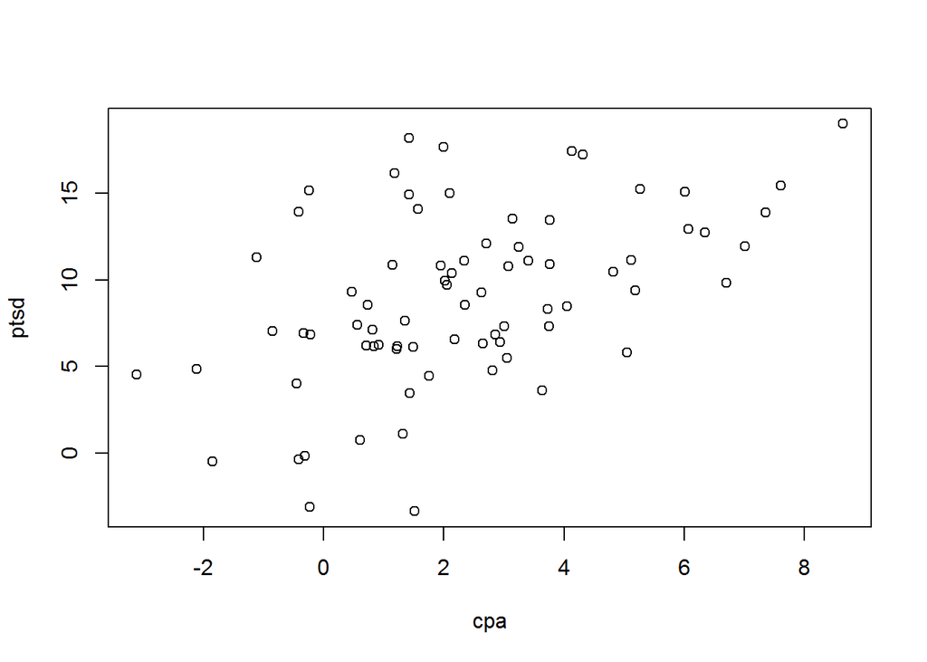

```r
plot(ptsd ~ cpa, sexab)
```

在看 ptsd 與 cpa (體罰) 的關係時，我們進一步分開看有沒有 csa 的差別

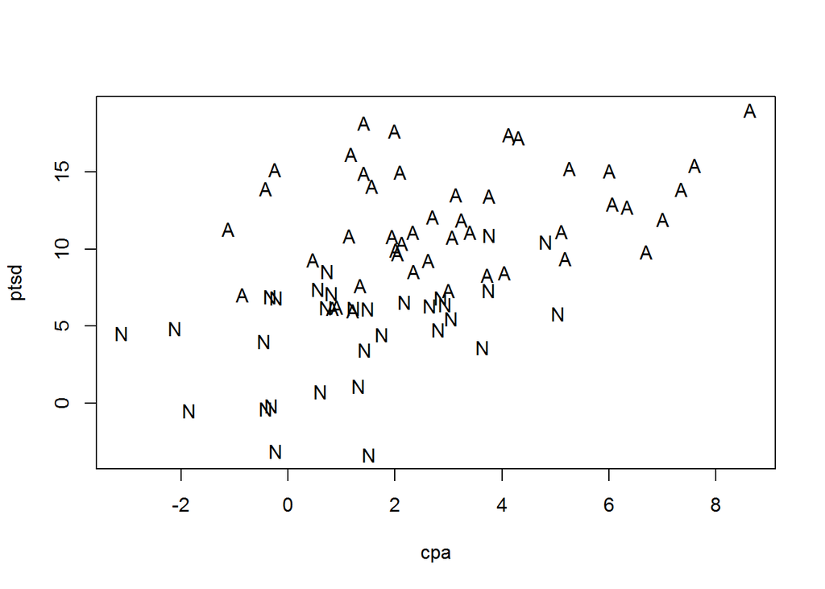

```r
plot(ptsd ~ cpa, pch = as.character(csa), sexab)
```

```r
g2 <- lm(ptsd ~ .,  data=sexab)
summary(g2)
```

```
##
## Call:
## lm(formula = ptsd ~ ., data = sexab)
##
## Residuals:
##     Min      1Q  Median      3Q     Max
## -8.1567 -2.3643 -0.1533  2.1466  7.1417
##
## Coefficients:
##             Estimate Std. Error t value Pr(>|t|)
## (Intercept)   3.9753     0.6293   6.317 1.87e-08 ***
## cpa           0.5506     0.1716   3.209  0.00198 **
## csaAbused     6.2728     0.8219   7.632 6.91e-11 ***
## ---
## Signif. codes:  0 '***' 0.001 '**' 0.01 '*' 0.05 '.' 0.1 ' ' 1
##
## Residual standard error: 3.273 on 73 degrees of freedom
## Multiple R-squared:  0.5786, Adjusted R-squared:  0.5671
## F-statistic: 50.12 on 2 and 73 DF,  p-value: 2.002e-14
```

## Note the change in the coefficient of CSA in g1 and g2.

After adjusting the effect of childhood physical abuse, our esitmate of the effect of childhood sexual abuse on PTSD is mildly reduced.

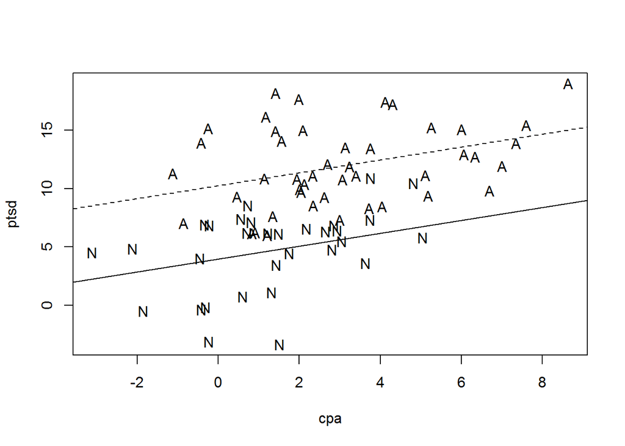

```r
plot(ptsd ~ cpa, pch=as.character(csa), sexab)
abline(3.975,0.551)
abline(3.975 + 6.273,0.551,lty=2)
```

## We can fit seperate regression lines model by adding an iteraction term:

```r
g3 <- lm(ptsd ~ cpa + csa + cpa:csa, sexab)
model.matrix(g3)
```

```
##    (Intercept)      cpa csaAbused cpa:csaAbused
## 1            1  2.04786         1       2.04786
## 2            1  0.83895         1       0.83895
## 3            1 -0.24139         1      -0.24139
## 4            1 -1.11461         1      -1.11461
## 5            1  2.01468         1       2.01468
## 6            1  6.71131         1       6.71131
## 7            1  1.20814         1       1.20814
## 8            1  2.34284         1       2.34284
## 9            1  0.91188         1       0.91188
## 10           1 -0.85308         1      -0.85308
## 11           1  7.35666         1       7.35666
## 12           1  2.09361         1       2.09361
## 13           1  1.94568         1       1.94568
## 14           1 -0.42222         1      -0.42222
```

[output cut: 67 more lines]

The interaction term cpa:csaAbused is represented in the fourth column of the matrix as the product of the second and third columns.

```r
summary(g3)
```

```
##
## Call:
## lm(formula = ptsd ~ cpa + csa + cpa:csa, data = sexab)
##
## Residuals:
##     Min      1Q  Median      3Q     Max
## -8.1999 -2.5313 -0.1807  2.7744  6.9748
##
## Coefficients:
##               Estimate Std. Error t value Pr(>|t|)
## (Intercept)     3.6959     0.7107   5.201 1.79e-06 ***
## cpa             0.7640     0.3038   2.515   0.0142 *
## csaAbused       6.8612     1.0747   6.384 1.48e-08 ***
## cpa:csaAbused  -0.3140     0.3685  -0.852   0.3970
## ---
## Signif. codes:  0 '***' 0.001 '**' 0.01 '*' 0.05 '.' 0.1 ' ' 1
##
## Residual standard error: 3.279 on 72 degrees of freedom
## Multiple R-squared:  0.5828, Adjusted R-squared:  0.5654
## F-statistic: 33.53 on 3 and 72 DF,  p-value: 1.133e-13
```

## Can you write down the regression equations for both Abused and NotAbused groups?

## The interaction term is not significant and the model can be simplified:

```r
g <- lm(ptsd ~ cpa + csa, sexab)
```

## The diagnostics:

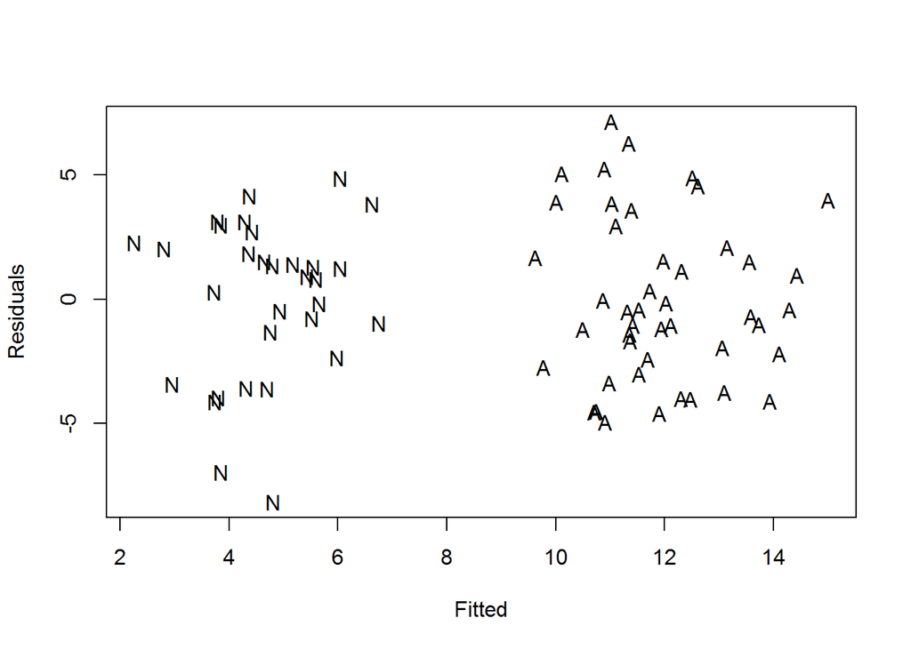

```r
plot(fitted(g),residuals(g),pch=as.character(sexab$csa),xlab="Fitted",ylab="Residuals")
```

# Factors with more than two levels

The response was the longevity of the fruitfly in days.

1. (isolated) One group was kept solitary, while
2. (low) another was kept individually with a virgin female each day.
3. (high) Another group was given 8 virgin females per day.
4. (one) As an additional control the fourth groups was kept with one pregnant females per day.
5. (many) As an additional control the fifth group was kept with eight pregnant females per day.

Pregnant fruitflies will not mate.

The thorax length of each male was measured as this was known to affect longevity. One observation in the many group has been lost.

```r
data(fruitfly)
ff = fruitfly
```

```r
str(fruitfly)
```

```
## 'data.frame':    124 obs. of  3 variables:
##  $ thorax   : num  0.68 0.68 0.72 0.72 0.76 0.76 0.76 0.76 0.76 0.8 ...
##  $ longevity: int  37 49 46 63 39 46 56 63 65 56 ...
##  $ activity : Factor w/ 5 levels "isolated","one",..: 4 4 4 4 4 4 4 4 4 4 ...
```

```r
head(fruitfly)
```

```
##   thorax longevity activity
## 1   0.68        37     many
## 2   0.68        49     many
## 3   0.72        46     many
## 4   0.72        63     many
## 5   0.76        39     many
## 6   0.76        46     many
```

```r
tail(fruitfly)
```

```
##     thorax longevity activity
## 119   0.88        47     high
## 120   0.88        54     high
## 121   0.88        54     high
## 122   0.88        56     high
## 123   0.88        60     high
## 124   0.92        44     high
```

```r
summary(fruitfly)
```

```
##      thorax         longevity         activity
##  Min.   :0.6400   Min.   :16.00   isolated:25
##  1st Qu.:0.7600   1st Qu.:46.00   one     :25
##  Median :0.8400   Median :58.00   low     :25
##  Mean   :0.8224   Mean   :57.62   many    :24
##  3rd Qu.:0.8800   3rd Qu.:70.00   high    :25
##  Max.   :0.9400   Max.   :97.00
```

## The response variable is longevity

### 如果是依 activity 分類列

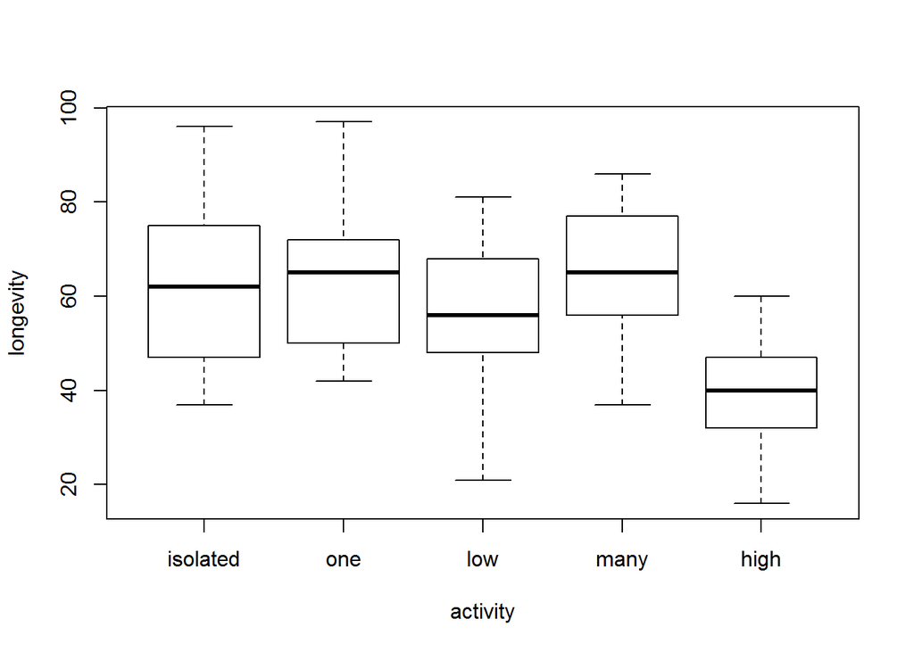

```r
plot(longevity ~ activity, ff)
```

### 如果是依 thorax 分類列

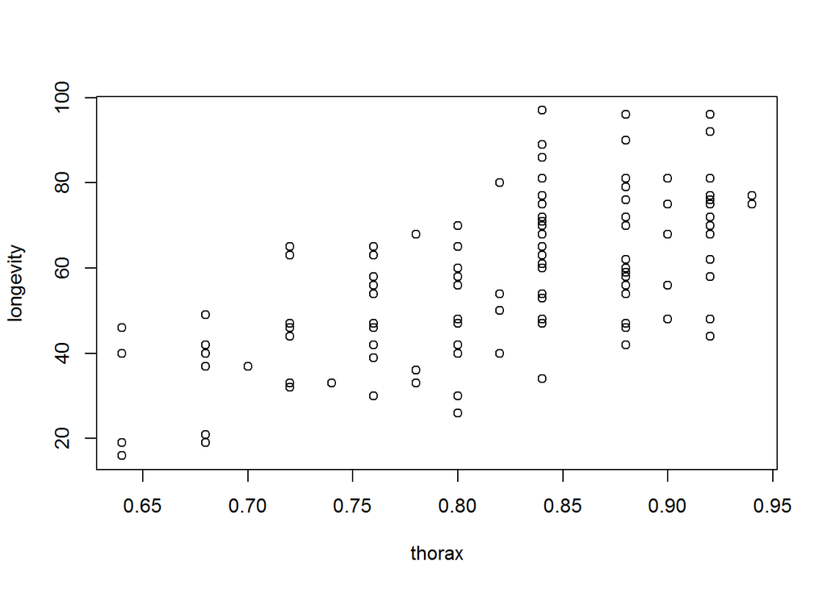

```r
plot(longevity ~ thorax, ff)
```

### 如果是看 thorax，但也分依 activity 分類列

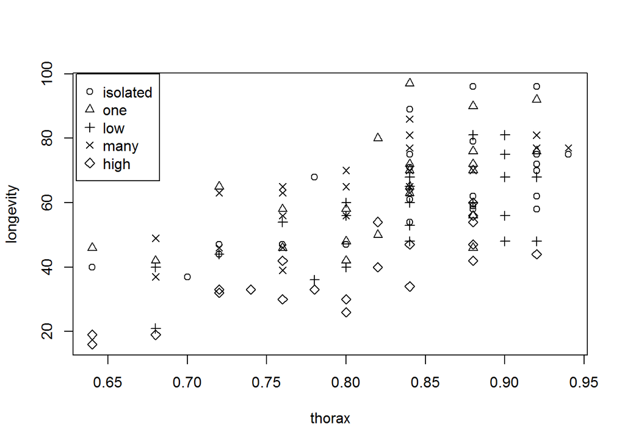

```r
plot(longevity ~ thorax, ff, pch=unclass(activity))
legend(0.63,100,levels(ff$activity),pch=1:5)
```

# 你們覺得怎麼樣？

```r
g <- lm(longevity ~ thorax*activity, ff)
summary(g)
```

```
##
## Call:
## lm(formula = longevity ~ thorax * activity, data = ff)
##
## Residuals:
##      Min       1Q   Median       3Q      Max
## -25.9509  -6.7296  -0.9103   6.1854  30.3071
##
## Coefficients:
##                     Estimate Std. Error t value Pr(>|t|)
## (Intercept)         -50.2420    21.8012  -2.305    0.023 *
## thorax              136.1268    25.9517   5.245 7.27e-07 ***
## activityone           6.5172    33.8708   0.192    0.848
## activitylow          -7.7501    33.9690  -0.228    0.820
## activitymany         -1.1394    32.5298  -0.035    0.972
## activityhigh        -11.0380    31.2866  -0.353    0.725
## thorax:activityone   -4.6771    40.6518  -0.115    0.909
## thorax:activitylow    0.8743    40.4253   0.022    0.983
## thorax:activitymany   6.5478    39.3600   0.166    0.868
## thorax:activityhigh -11.1268    38.1200  -0.292    0.771
## ---
## Signif. codes:  0 '***' 0.001 '**' 0.01 '*' 0.05 '.' 0.1 ' ' 1
##
## Residual standard error: 10.71 on 114 degrees of freedom
## Multiple R-squared:  0.6534, Adjusted R-squared:  0.626
## F-statistic: 23.88 on 9 and 114 DF,  p-value: < 2.2e-16
```

## The above model is equivalent to g <- lm(longevity ~ thorax + activity + thorax:activity, ff)

## Since “isolated” is the refence level, the fitted regression line within this group is longevity = -50.242 + 136.1268*thorax

## For “one”, it is longevity = (-50.242 + 6.5172) + (136.1268 - 4.6771)* thorax

## How to interpret the p-values?

```r
anova(g)
```

```
## Analysis of Variance Table
##
## Response: longevity
##                  Df  Sum Sq Mean Sq F value    Pr(>F)
## thorax            1 15003.3 15003.3 130.733 < 2.2e-16 ***
## activity          4  9634.6  2408.6  20.988 5.503e-13 ***
## thorax:activity   4    24.3     6.1   0.053    0.9947
## Residuals       114 13083.0   114.8
## ---
## Signif. codes:  0 '***' 0.001 '**' 0.01 '*' 0.05 '.' 0.1 ' ' 1
```

## This is a sequential analysis of variance table.

Starting from a null model, terms are added and sequentially tested.

## The interaction term thorax:activity is not significant indicating that we can fit the same slope with each group.

#### Diagnostics

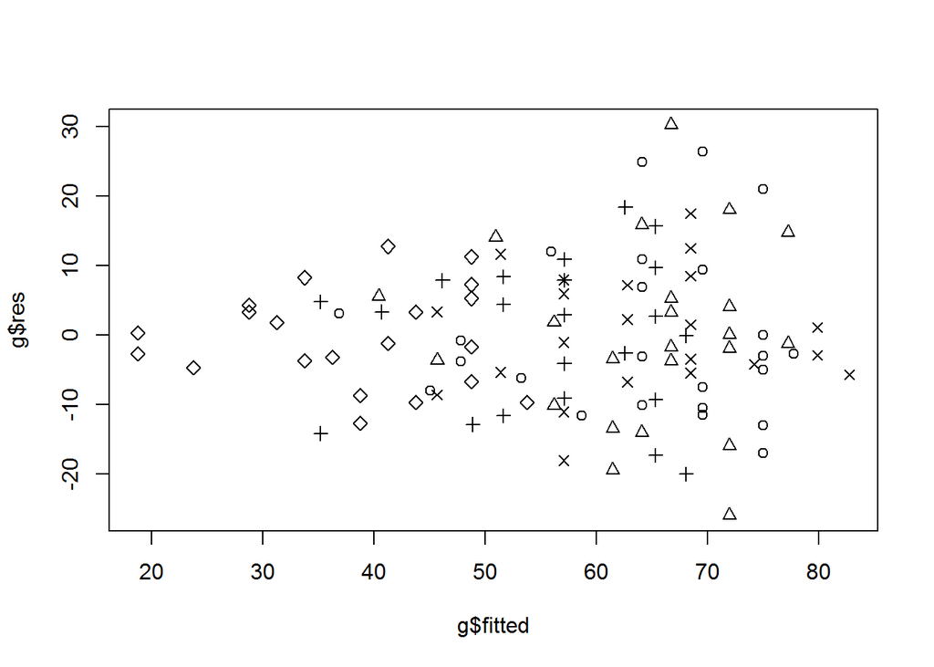

```r
plot(g$res ~ g$fitted,pch=unclass(ff$activit))
```

Nonconstant variance. It does not appear to be related the five groups. Log tranformation on “longevity” should help.

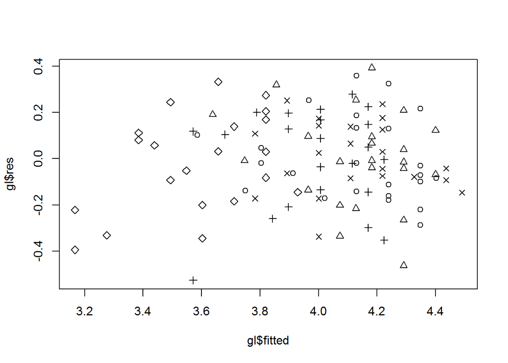

```r
gl <- lm(log(longevity) ~ thorax+activity, ff)
plot(gl$res ~ gl$fitted, pch=unclass(ff$activity))
```

```r
summary(gl)
```

```
##
## Call:
## lm(formula = log(longevity) ~ thorax + activity, data = ff)
##
## Residuals:
##      Min       1Q   Median       3Q      Max
## -0.52641 -0.13629 -0.00823  0.13918  0.39273
##
## Coefficients:
##              Estimate Std. Error t value Pr(>|t|)
## (Intercept)   1.84421    0.19882   9.276 1.04e-15 ***
## thorax        2.72146    0.23329  11.666  < 2e-16 ***
## activityone   0.05174    0.05468   0.946   0.3459
## activitylow  -0.12387    0.05463  -2.268   0.0252 *
## activitymany  0.08791    0.05546   1.585   0.1156
## activityhigh -0.41925    0.05527  -7.586 8.35e-12 ***
## ---
## Signif. codes:  0 '***' 0.001 '**' 0.01 '*' 0.05 '.' 0.1 ' ' 1
##
## Residual standard error: 0.1931 on 118 degrees of freedom
## Multiple R-squared:  0.7025, Adjusted R-squared:  0.6899
## F-statistic: 55.72 on 5 and 118 DF,  p-value: < 2.2e-16
```

## We can interpret the coefficients as having a multiplicative effect:

```r
coef(gl)
```

```
##  (Intercept)       thorax  activityone  activitylow activitymany
##   1.84420988   2.72145811   0.05174431  -0.12386729   0.08790959
## activityhigh
##  -0.41925210
```

```r
exp(coef(gl)[3:6])
```

```
##  activityone  activitylow activitymany activityhigh
##    1.0531064    0.8834971    1.0918894    0.6575384
```

```r
exp(coef(gl)[4])/exp(coef(gl)[6])
```

```
## activitylow
##    1.343643
```

## This means that the low activity group has a 34% increase in lifespan compared to the high activity group.